# Transparent Classroom Data School Profile

Equity in lesson introduction and mastery

Lee LeBoeuf, Ph.D. candidate at The University of Virginia

# Introduction

This file contains three sets of visualizations from your school’s Transparent Classroom data for the 2021-2022 school year. I focused on lessons that were recorded as being “introduced” or “mastered” in Transparent Classroom, and I divided each set of visualizations into the three classroom levels in your school: primary, lower elementary, and upper elementary. For each set of graphs, you can click on the different tabs to see data for each specific level and lesson type.

Here is a brief summary of what you’ll find below:

- Figures showing the percent of students in each racial group and the percent of all lessons given to each racial group.
- Figures showing the average cumulative number of lessons given to students in each racial group in each month across the school year.
- Figures showing the variability in total lessons given across the school year to each student across different lesson subjects and racial groups.

An important note: I understand that with these data, I have only a narrow view into your school. You know your students, your classrooms, and thousands of important pieces of information that will give these data context; I do not. In creating these graphs, I wanted to provide an opportunity for your school to reflect on the data based on your own understanding about what is happening in your school. Therefore, I provide information about how to interpret the different graphs, but I refrain from drawing conclusions about what is shown. In short: I hope this file poses more questions than it answers! More than anything, this file is meant to serve as a sincere thank you for participating in my study. I hope this file and subsequent conversations around it are as useful to you as you have been to me in advancing my research. **Thank you!**

## Important notes about the data:

- Protecting the anonymity of both students and teachers was a priority. As a result, I do not show any data for an individual classroom at a time. I also only show data for racial groups that included 10 or more students to prevent students from being identified by their data. For your school, this means that the only racial groups included are White, Black, and Multiracial. I also had to remove data for which the racial group was missing.
- These are based on lessons that were *recorded in Transparent Classroom*. It is unlikely that these data reflect every lesson delivered across the school year—many were likely not recorded for various reasons, and each teacher may use Transparent Classroom with varying consistency.
- Each graph includes a caption with the number of students represented in the graph. For some graphs, I had to make more exclusions, which are described below when relevant.
- In creating these files, I used the anonymous Transparent Classroom School ID for each school. Therefore, I do not know which data came from which school.

# All lessons delivered

In the graphs below, the panel on the right shows the percent of students who are Black, Multiracial, or White, and the panel on the left shows the percent of all lessons that were recorded as introduced or mastered by Black, Multiracial, and White students. For example, if looking at the lessons introduced in primary, if 30% of the primary students are Black and 35% of the lessons introduced in primary were given to Black students, then you would see a 30% on the right side and 35% on the left side.

In a perfectly equitable world, you would see equal numbers on both sides—if 40% of the students are White, we could reasonably expect that 40% of the lessons given were given to White students.

Questions to consider as you look at these graphs:

- Are these breakdowns what you would expect to see in your school?
- Where do you notice more equity and where do you notice larger gaps? In introduced or mastered lessons?

## Percent of students in each racial group and percent of lessons given to each race

### Primary

#### Introduced

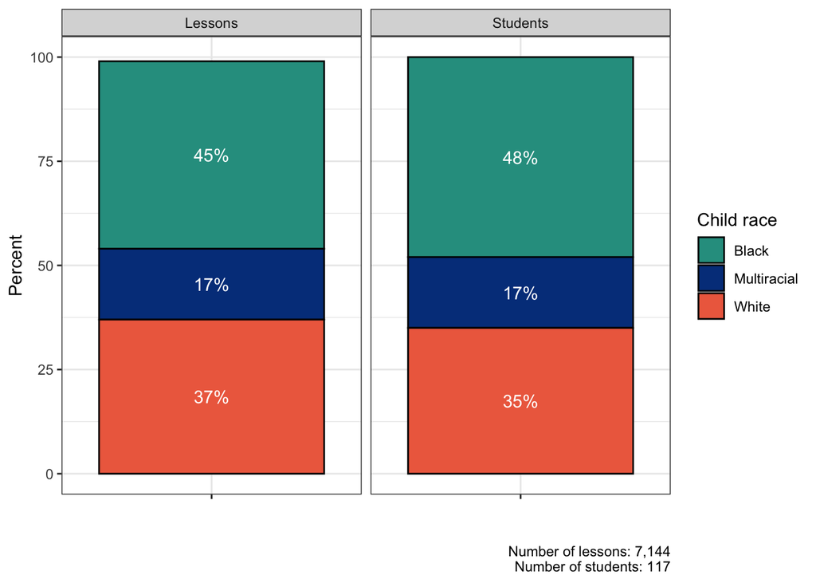

#### Mastered

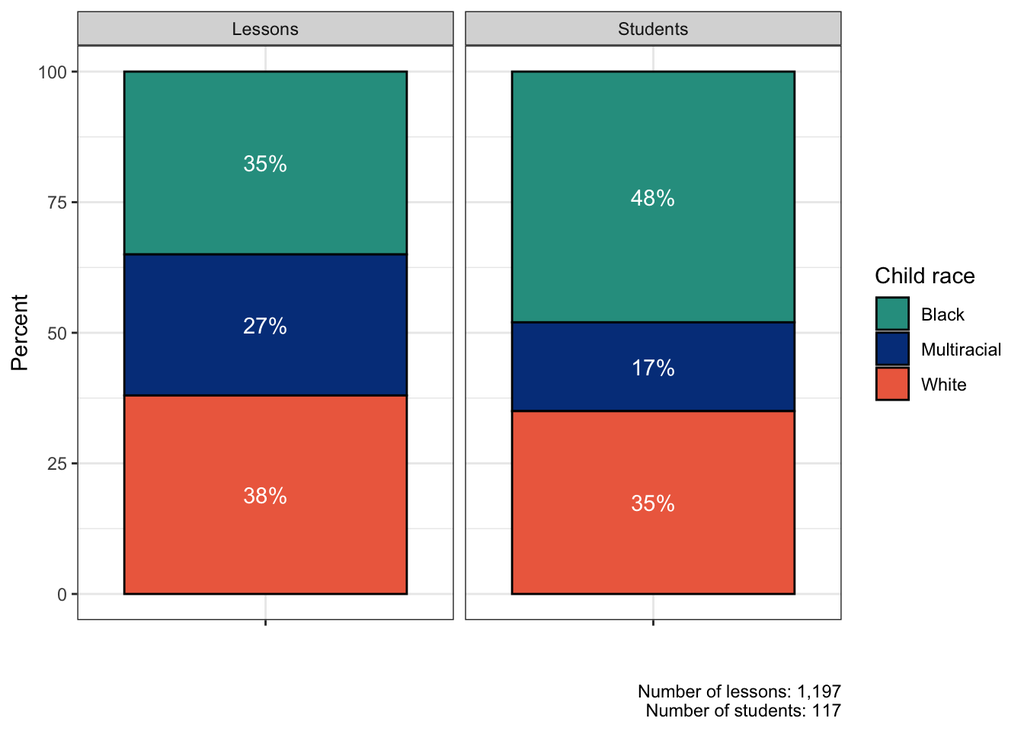

### Lower Elementary

#### Introduced

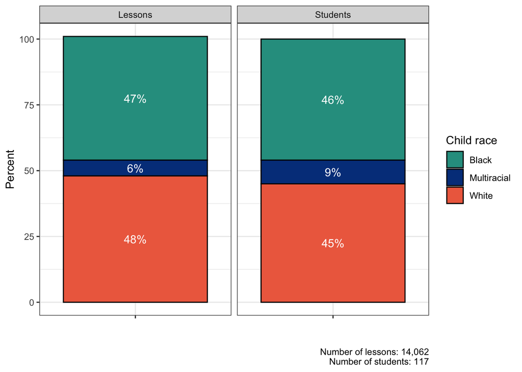

#### Mastered

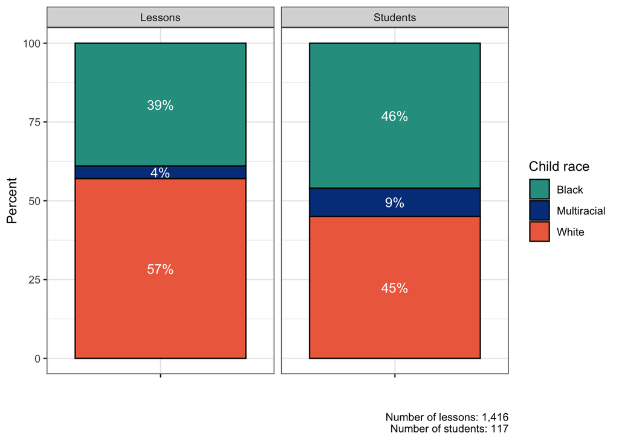

### Upper Elementary

#### Introduced

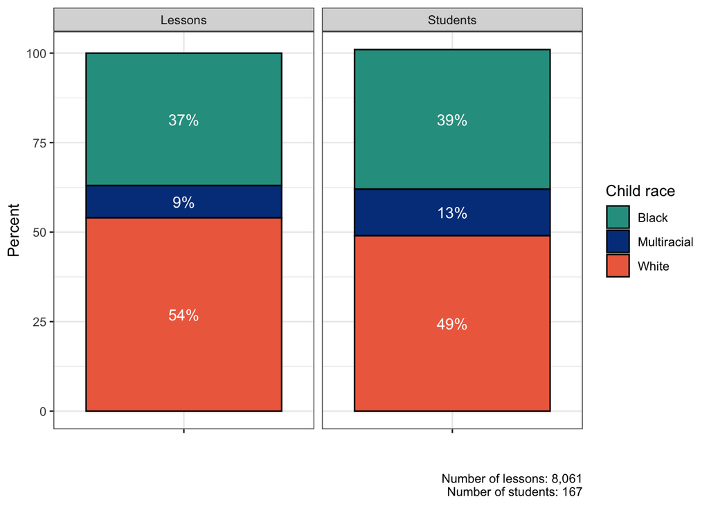

#### Mastered

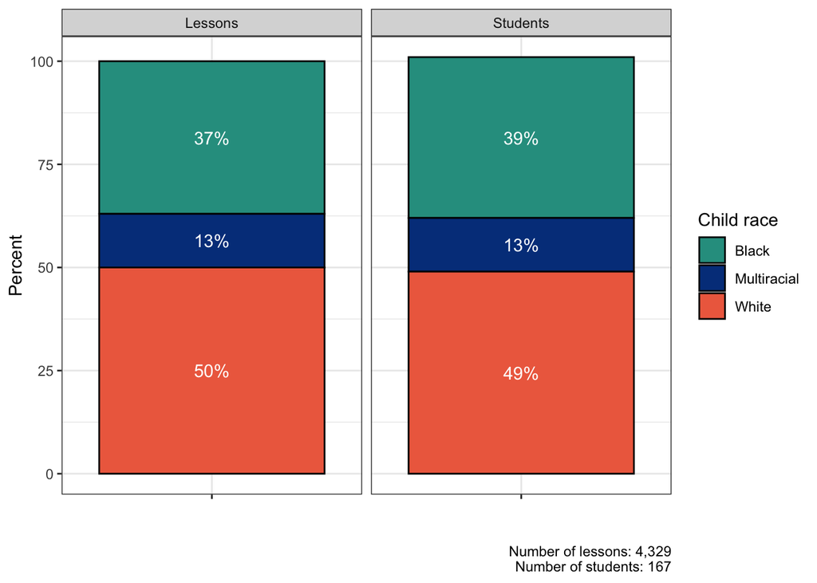

# Average growth over the school year

The following graphs show the average cumulative number of lessons given to students of different racial groups across the school year. Each point shows the average total number of lessons students of that racial group received by the end of that month. In other words, a value of 50 in September would mean that by the end of September, on average, students of a given racial group have received 50 lessons.

You will see in some places below that the number of lessons given to a students varies by race. These plots include a caption that provides the gap between the highest and lowest average number of lessons at the beginning of the year (September) and the end of the year (May).

**Note:** For these graphs, the average is based on the number of recorded lessons for each student in each month. In some cases, there were no lessons recorded for certain students in a specific month. I assume these were cases where a student may have transferred schools or was absent for much of a given month. This resulted in misleading dips in the graph. For example, imagine a child named Jeremy is introduced to the most number of lessons in primary, and he brings up the average each month for primary students. If Jeremy doesn’t come to school in February and so no lessons are recorded for him that month, the average for February would appear much lower. To avoid confusion over cases like this, the following graphs *only show data for students who had lessons recorded for them for 7 or more months in the school year*. That is, if teachers only recorded introducing lessons to a student in September and October, they were not included in the graphs below. You will quickly notice that many fewer students had lessons recorded as mastered for 7 months out of the school year than those who had lessons recorded as introduced—I imagine this is simply a function of how teachers prefer to use Transparent Classroom!

Questions to consider as you look at these graphs:

- What might the lines for introduced and mastered lessons say about the average student’s growth across the school year?
- Does anything stand out to you as you look at differences and similarities across the primary, lower elementary, and upper elementary levels?

## Average number of lessons received over time by race

### Primary

#### Introduced

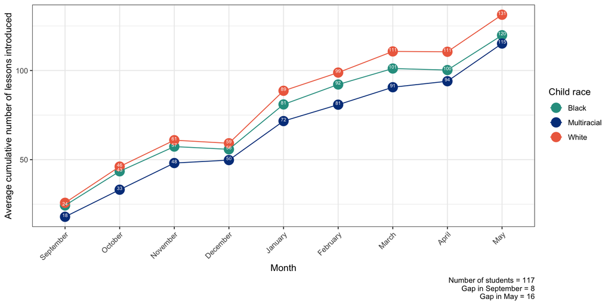

#### Mastered

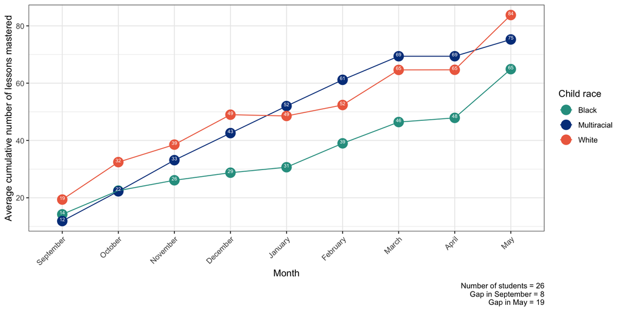

### Lower Elementary

#### Introduced

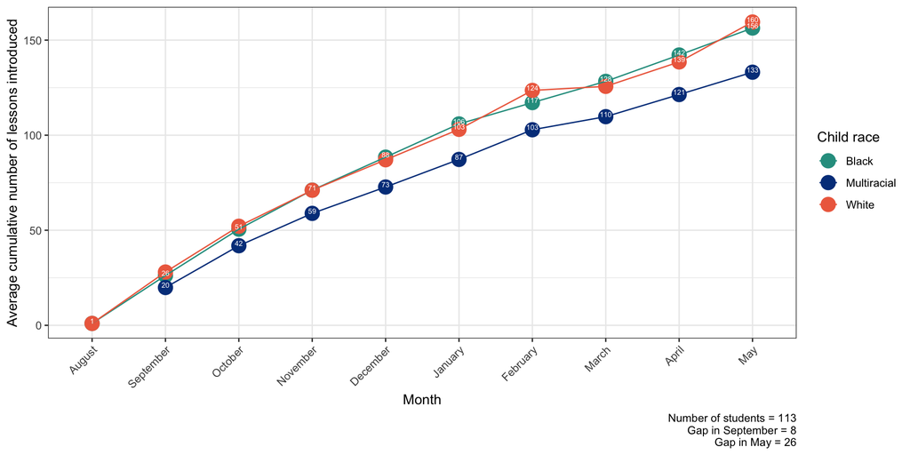

#### Mastered

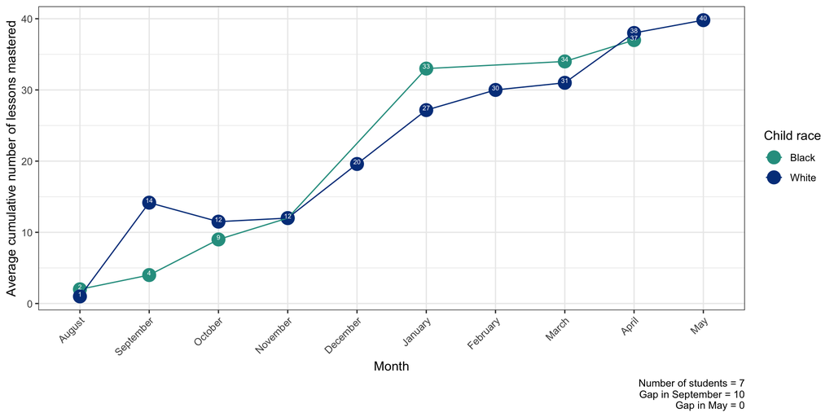

### Upper Elementary

#### Introduced

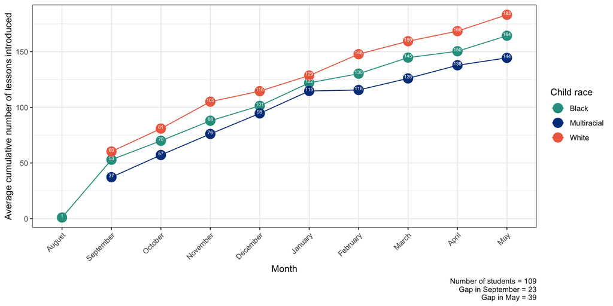

#### Mastered

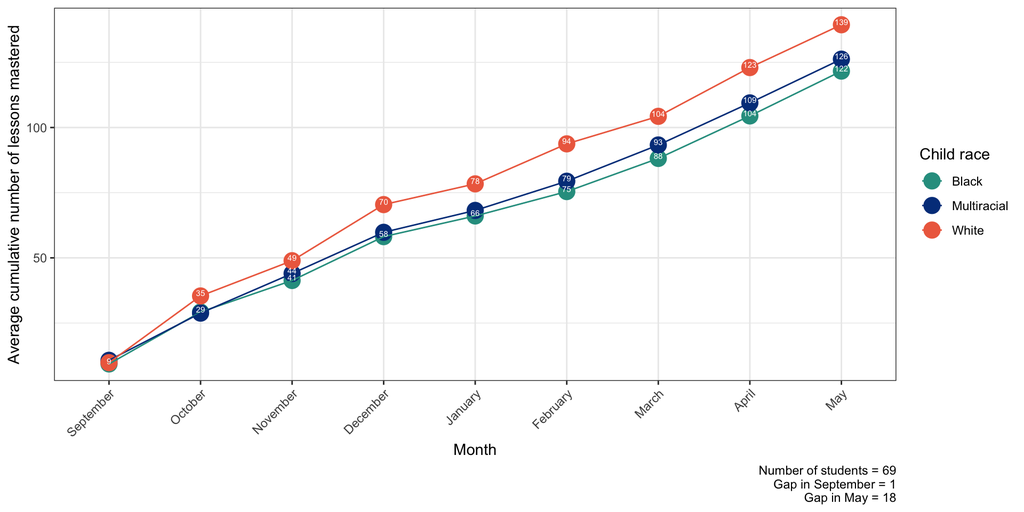

# All lessons by subject

The following graphs are meant to show variability in the number of total lessons introduced to and mastered by students in each subject across the entire school year. These plots are called violin plots, because for many of them the resulting shape looks like a violin!

To make interpretation of a violin plot clear, imagine that you told all the students in your school to arrange themselves in a line based on their birthday month. The line would be 12 groups long (one for each month), and some months would have many students grouped together, while others would only have a few students. Now imagine you could look at that line from a bird’s eye view—the months with many students would appear wider, and the months with only a few students would appear very thin.

A violin plot shows essentially the same thing as the line described above. In our case, when many students were introduced to the same number of lessons in a subject, the shape appears wider at that corresponding number of lessons along the y-axis. When a violin plot looks like a thin, stretched-out line, it means that there is a lot of variability in the number of lessons received: In other words, few students were introduced to the same number of lessons in a subject. Some students were introduced to many lessons, some very little, and others fell everywhere between.

**Note:** These graphs, unlike the graphs above, include all students for each racial group. The data were not filtered to only include students who had lessons recorded for them for 7 or more months in the school year.

Questions to consider as you look at these graphs:

- What subjects show the highest amount of variability? Which show the least?
- What do you notice about the amount of variability across primary, lower elementary, and upper elementary? Does that raise any questions for you?
- What does it mean for students at the top and bottom of each violin? These are the students who were introduced to or demonstrated mastery over the most and least number of lessons.

## Total lessons received in each subject by race

### Primary

#### Introduced

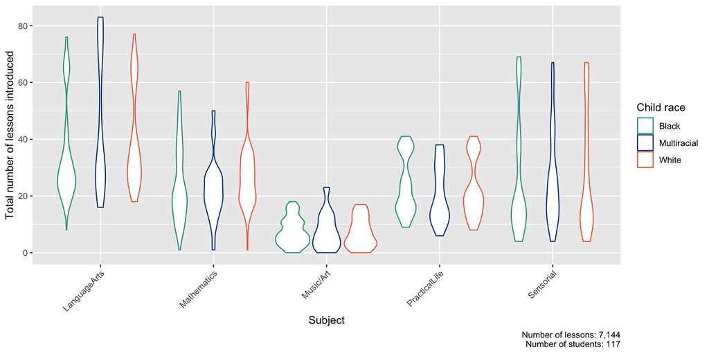

#### Mastered

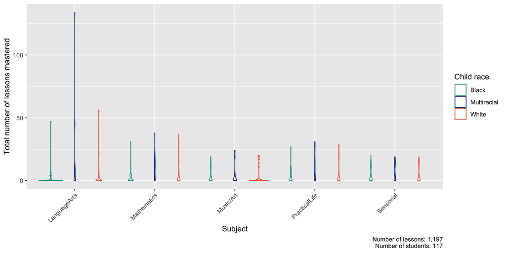

### Lower Elementary

#### Introduced

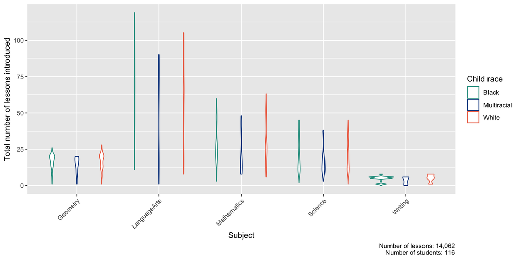

#### Mastered

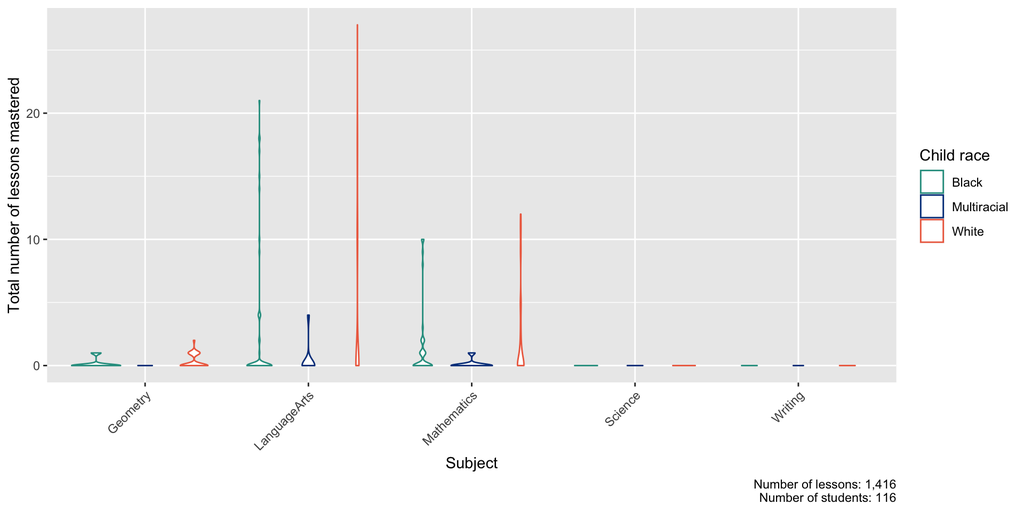

### Upper Elementary

#### Introduced

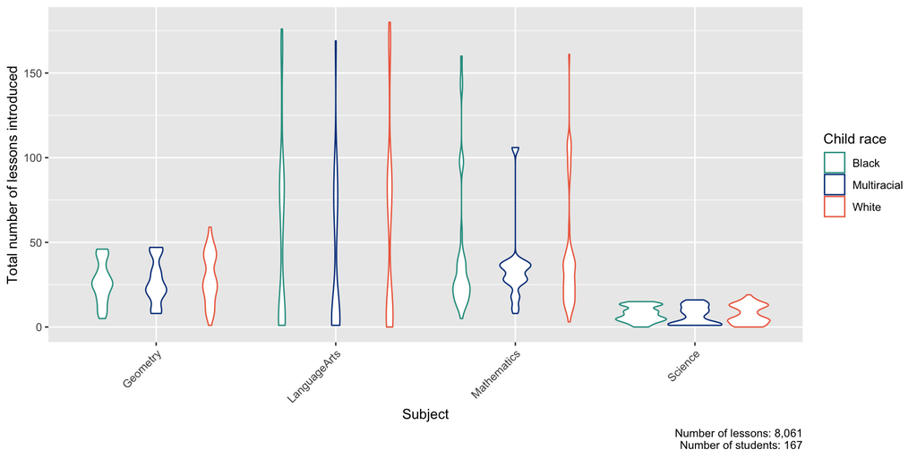

#### Mastered

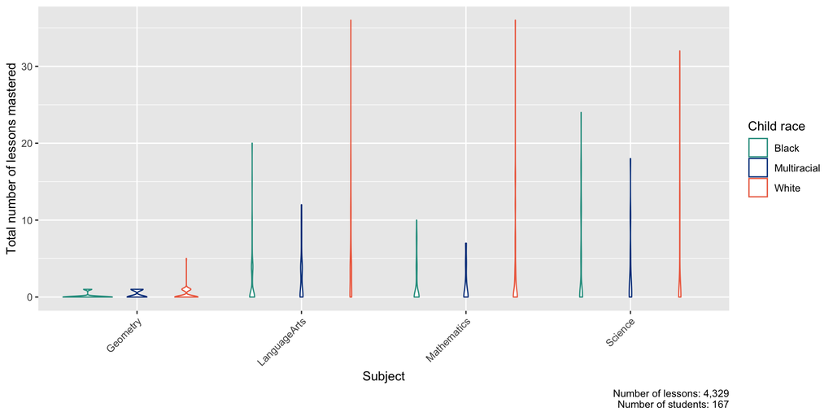